# R Lab 9 Key

## Setting Up

### Libraries

```r
library(tidyverse)
library(ggplot2)
library(psych)
library(viridis)
library(openintro)
```

## Data: Stent Data

This data comes from an experiment that examined whether implanting a stent in the brain of a patient at risk for a stroke helps reduce the risk of a stroke. The results from the first 30 days of this study, which included 451 patients, are summarized in the below table. These results are surprising! *The point estimate suggests that patients who received stents may have a higher risk of stroke*: p<sub>treatment</sub> - p<sub>control</sub> = 0.090.

| Group | No event | Stroke |
| --- | --- | --- |
| control | 214 | 13 |
| treatment | 191 | 33 |
| **Total** | 405 | 46 |

Consider the stent study and results. The conditions necessary to ensure the point estimate p<sub>treatment</sub> - p<sub>control</sub> = 0.090 is nearly normal have been verified for you, and the estimate’s standard error is SE = 0.028.

### EXERCISE 1: Stent 95% CI

Construct a 95% confidence interval for the change in 30-day stroke rates from usage of the stent.

Reminder, use the formula: point estimate ± 1.96 × SE.

You will create two objects. Create `stent.lower` which is assigned the value of point estimate - 1.96 × SE. Create `stent.higher` which is assigned the value of point estimate + 1.96 × SE.

```r
stent.lower <- 0.090 - 1.96 * 0.028
stent.higher <- 0.090 + 1.96 * 0.028
```

If you correctly created the objects in the previous chunk, the below chunk will run without error and print the lower and upper bounds of the 95% confidence interval.

```r
stent.lower
```

```
## [1] 0.03512
```

```r
stent.higher
```

```
## [1] 0.14488
```

### EXERCISE 2: Stent 95% CI Interpretation

Interpret the 95% confidence intervals and what they mean in the context of the point estimate.

We are 95% confident that implanting a stent in a stroke patient’s brain increased the risk of stroke within 30 days by a rate of 0.035 to 0.145. This confidence interval can also be used in a way analogous to a hypothesis test: since the interval does not contain 0 (is completely above 0), it means the data provide convincing evidence that the stent used in the study changed the risk of stroke within 30 days.

### EXERCISE 3: Stent 95% CI Graph

Below I create a dataset with a normal distribution around the point estimate of 0.09 and the standard error of 0.028. Run the chunk and do not make any changes.

```r
stent_norm <- rnorm(mean = 0.090, sd = 0.028, n = 451) %>% as.data.frame()
names(stent_norm) <- "rate"
```

In the code chunk below, use `geom_density()` to plot the distribution of `rate` in the `stent_norm` dataset. Inside of `geom_density()`, set `fill =` to a color of your choice. Add a `geom_vline` that represents the point estimate of 0.090 with `color = "red"` and `size = 1`. Add a `geom_vline` that represents the point estimates of `stent.lower` and `stent.higher` with `color = "orange"`, `linetype = "longdash"`, and `size = 1`.

Finally, make sure you add a theme.

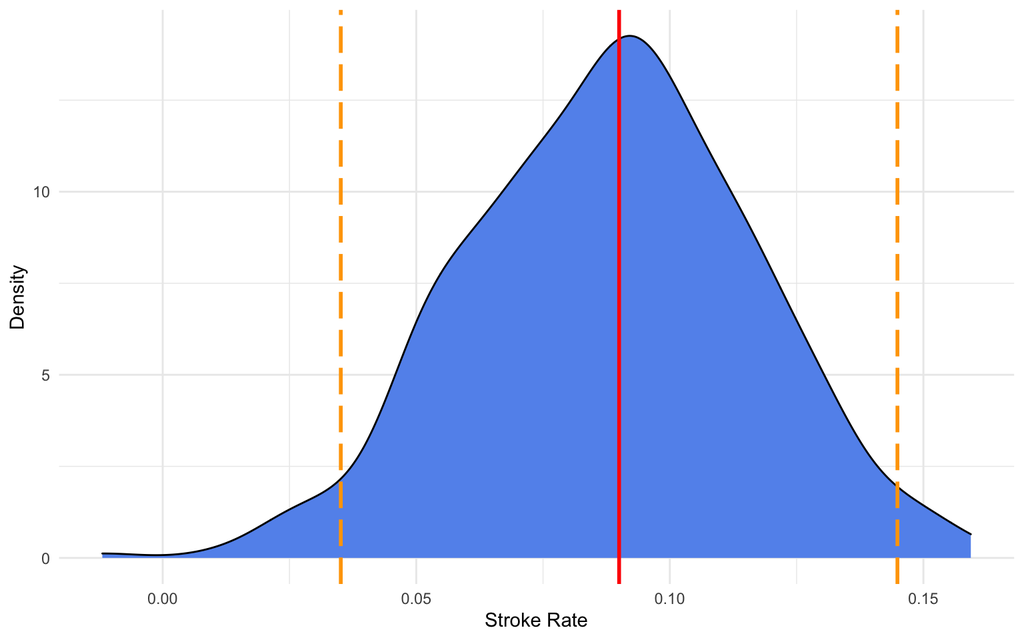

```r
ggplot(stent_norm, aes(rate)) +
  geom_density(fill = "cornflowerblue") +
  theme_minimal() +
  geom_vline(xintercept = 0.090, color = "red", size = 1) +
  geom_vline(xintercept = c(stent.lower, stent.higher), color = "orange", linetype = "longdash", size = 1) +
  labs(x = "Stroke Rate", y = "Density")
```

## Data: Twitter users and news

A poll conducted in 2013 found that 52% of U.S. adult Twitter users get at least some news on Twitter. The standard error for this estimate was 2.4%, and a normal distribution may be used to model the sample proportion. (Pew Research Center 2013b)

### EXERCISE 4: Twitter News 95% CI

Construct a 95% confidence interval for amount of U.S. adult twitter uses who get at least some news from twitter.

Reminder, use the formula: point estimate ± 1.96 × SE.

You will create two objects. Create `twitter.lower` which is assigned the value of point estimate - 1.96 × SE. Create `twitter.higher` which is assigned the value of point estimate + 1.96 × SE.

```r
twitter.lower <-  52 - 1.96 * 2.4
twitter.higher <- 52 + 1.96 * 2.4
```

If you correctly created the objects in the previous chunk, the below chunk will run without error and print the lower and upper bounds of the 95% confidence interval.

```r
twitter.lower
```

```
## [1] 47.296
```

```r
twitter.higher
```

```
## [1] 56.704
```

### EXERCISE 5: Twitter News 95% CI Interpretation

Interpret the 95% confidence intervals and what they mean in the context of the point estimate.

### EXERCISE 6: Twitter News 95% CI Graph

Below I create a dataset with a normal distribution around the point estimate of 52 and the standard error of 2.4. Run the chunk and do not make any changes.

```r
twitter_norm <- rnorm(mean = 52, sd = 2.4, n = 1000) %>% as.data.frame()
names(twitter_norm) <- "percent"
```

In the code chunk below, use `geom_density()` to plot the distribution of `percent` in the `twitter_norm` dataset. Inside of `geom_density()`, set `fill =` to a color of your choice. Add a `geom_vline` that represents the point estimate of 52 with `color = "red"` and `size = 1`. Add a `geom_vline` that represents the point estimatew of `twitter.lower` and `twitter.higher` with `color = "orange"`, `linetype = "longdash"`, and `size = 1`.

Finally, make sure you add a theme.

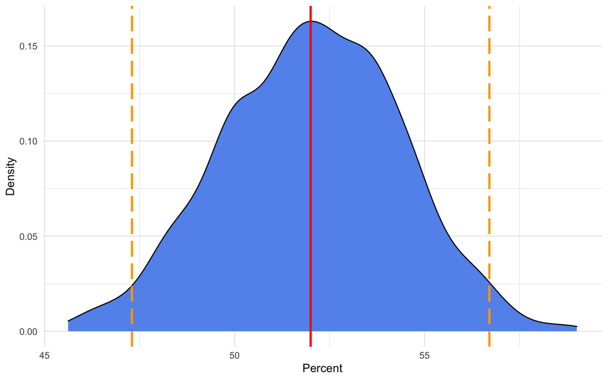

```r
ggplot(twitter_norm, aes(percent)) +
  geom_density(fill = "cornflowerblue") +
  theme_minimal() +
  geom_vline(xintercept = 52, color = "red", size = 1) +
  geom_vline(xintercept = c(twitter.lower, twitter.higher), color = "orange", linetype = "longdash", size = 1) +
  labs(x = "Percent", y = "Density")
```

## Mental health

The General Social Survey asked the question: “For how many days during the past 30 days was your mental health, which includes stress, depression, and problems with emotions, not good?” Based on responses from 1,151 US residents, the survey reported a 95% confidence interval of 3.40 to 4.24 days in 2010.

### EXERCISE 7: Interpret 95% CI

Interpret this interval in context of the data. What does “95% confident” mean? Explain in the context of the application.

### EXERCISE 8: 99% CI

Suppose the researchers think a 99% confidence level would be more appropriate for this interval. Will this new interval be smaller or wider than the 95% confidence interval?

#### References

This Lab comes in part from the textbook Introduction to Modern Statistics.